# Project 2: Data Mining, Classification, Prediction

SDS322E : Elements of Data Science

## Filina Nurcahya-Tjoa UTEID : fnt226

For this project, I’m going to use the same data set as I used in my first project. However, instead of focusing on COVID related variables, I’m going to focus on how the population is affected by various factors related to wealth and resources. These datasets were collected in the year of 2020. They are a total of 51 observations. I got my data set from Kaggle.

The variables I’m going to focus on are :

Population - The number of people that live in a particular state.

Gini - A measure of how wealth is distributed within a population. The higher the value, the more wealth inequality exists.

ICU Beds - The number of beds in the ICU available within each state.

Income - The average income for a household in each state.

GDP (Gross Domestic Product) - The monetary value of all finished goods and services made within a state during a specific period. Could be used as a measure of growth and productivity.

I also created a new variable called “Pop.Density.Level” where states with a population density of over a hundred are considered a “high” population density state while states with population densities less than a hundred are considered a “low” population density state. These are denoted with a 1 and 0 respectively. There are 27 “high” population density states and 24 “low” population density states.

```r
library(tidyverse)
library(gt)
library(caret)

dataset <- read.csv("COVID19_state.csv")
dataset <- dataset %>%
    select(1:10)
dataset <- dataset %>%
    mutate(Pop.Density.Level = case_when(Pop.Density > 100 ~
        "1", Pop.Density < 100 ~ "0"))
sum(dataset$Pop.Density.Level == 1)
```

```
## [1] 27
```

```r
sum(dataset$Pop.Density.Level == 0)
```

```
## [1] 24
```

```r
rownames(dataset) <- dataset$State
dataset <- dataset %>%
    select(-c(Pop.Density, Infected, Deaths, State))
```

### Clustering

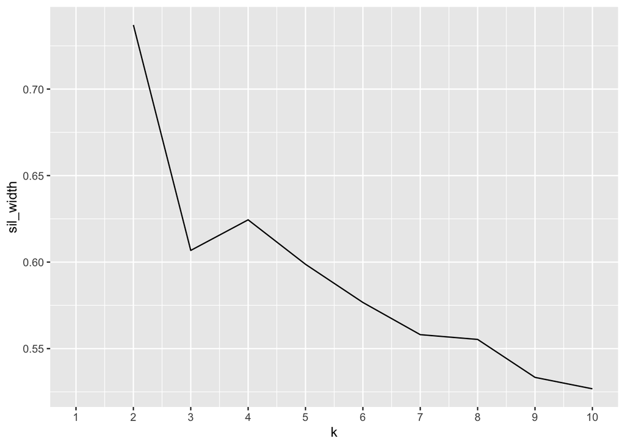

```r
library(cluster)
library(GGally)

# Selecting Variables to Cluster
pam_data <- dataset %>%
    select(Tested, Income, GDP)

# Finding the Suggested Number of Clusters.
sil_width <- vector()

for (i in 2:10) {
    pam_fit <- pam(pam_data, k = i)
    sil_width[i] <- pam_fit$silinfo$avg.width
}
ggplot() + geom_line(aes(x = 1:10, y = sil_width)) + scale_x_continuous(name = "k",
    breaks = 1:10)
```

```r
# Performing Clustering
pam1 <- pam_data %>%
    pam(2)
pam1 %>%
    head(6)
```

```
## $medoids
##          Tested Income   GDP
## Alabama 1356420  42334 45219
## Texas   8291703  49161 61167
##
## $id.med
## [1]  2 44
##
## $clustering
##               Alaska              Alabama             Arkansas
##                    1                    1                    1
##              Arizona           California             Colorado
##                    1                    2                    1
##          Connecticut District of Columbia             Delaware
##                    1                    1                    1
##              Florida              Georgia               Hawaii
##                    2                    1                    1
##                 Iowa                Idaho             Illinois
##                    1                    1                    2
##              Indiana               Kansas             Kentucky
##                    1                    1                    1
##            Louisiana        Massachusetts             Maryland
##                    1                    2                    1
##                Maine             Michigan            Minnesota
##                    1                    2                    1
##             Missouri          Mississippi              Montana
##                    1                    1                    1
##       North Carolina         North Dakota             Nebraska
##                    1                    1                    1
##        New Hampshire           New Jersey           New Mexico
##                    1                    1                    1
##               Nevada             New York                 Ohio
##                    1                    2                    1
##             Oklahoma               Oregon         Pennsylvania
##                    1                    1                    1
##         Rhode Island       South Carolina         South Dakota
##                    1                    1                    1
##            Tennessee                Texas                 Utah
##                    1                    2                    1
##             Virginia              Vermont           Washington
##                    1                    1                    1
##            Wisconsin        West Virginia              Wyoming
##                    1                    1                    1
##
## $objective
##   build    swap
## 1396266 1359175
##
## $isolation
##  1  2
## no no
## Levels: no L L*
##
## $clusinfo
##      size max_diss av_diss diameter separation
## [1,]   44  3365559 1013942  4587785   287655.9
## [2,]    7 10620814 3529211 13904226   287655.9
```

```r
pam_data %>%
    slice(pam1$id.med)
```

```
##          Tested Income   GDP
## Alabama 1356420  42334 45219
## Texas   8291703  49161 61167
```

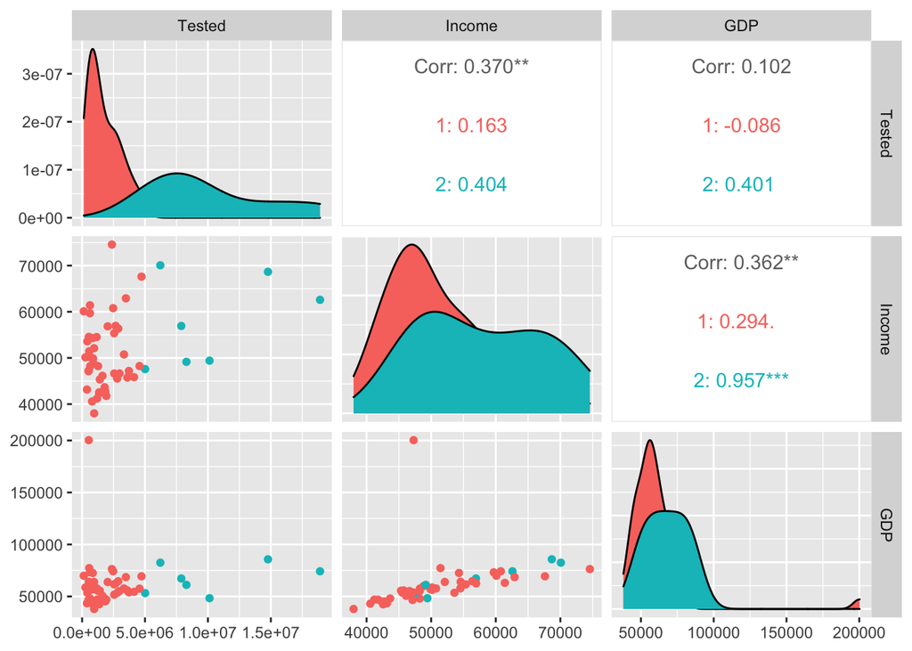

```r
# Visualize the Data using GGpairs.

ggpairs(pam_data, columns = 1:3, aes(color = as.factor(pam1$clustering)))
```

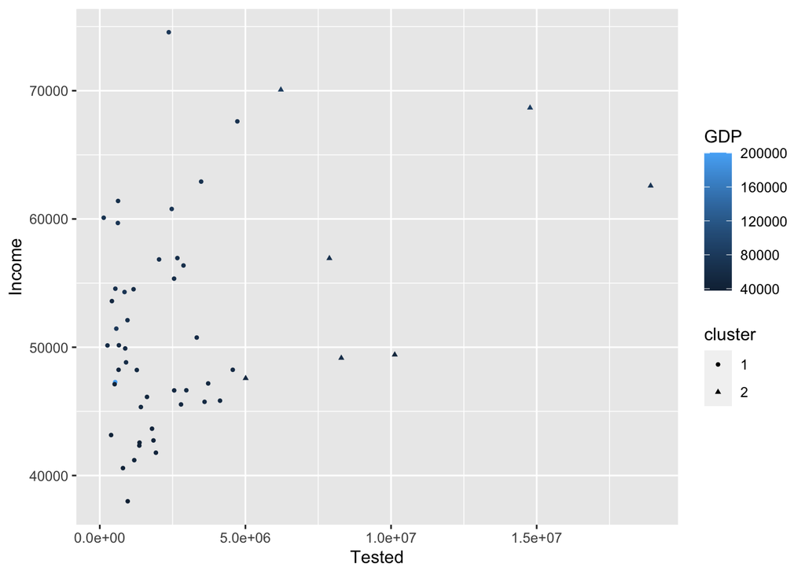

```r
pamclust <- pam_data %>%
    mutate(cluster = as.factor(pam1$clustering))
pamclust %>%
    ggplot(aes(Tested, Income, color = GDP, shape = cluster)) +
    geom_point(size = 1)
```

```r
# Silhouette Plot of Model.

pam1$silinfo$avg.width %>%
    head(6)
```

```
## [1] 0.7370499
```

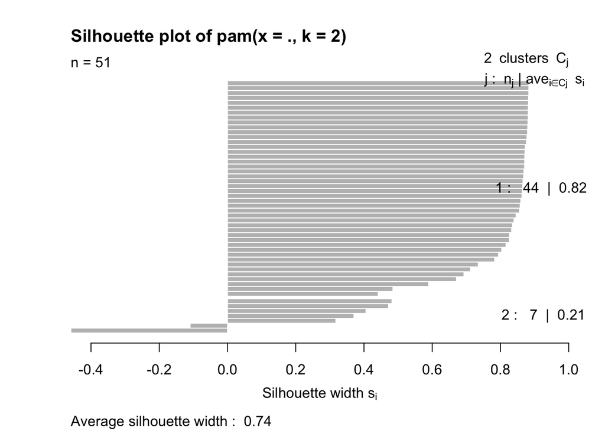

```r
plot(pam1, which = 2)
```

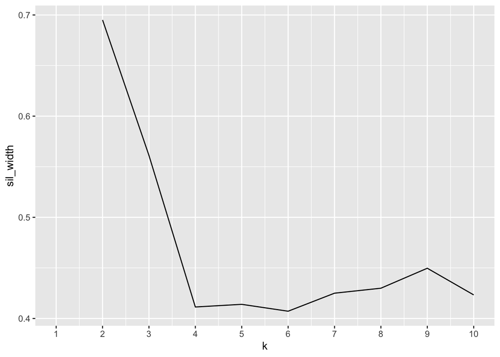

```r
# Clustering based on Gower Dissimilarities.
gower_data <- dataset %>%
    select(Income, Tested, GDP, Pop.Density.Level)
gower_data$Pop.Density.Level <- as.factor(gower_data$Pop.Density.Level)

gower <- daisy(gower_data, metric = "gower")

silwidth <- vector()

for (i in 2:10) {
    pam_fit <- pam(gower, diss = TRUE, k = i)
    sil_width[i] <- pam_fit$silinfo$avg.width
}

ggplot() + geom_line(aes(x = 1:10, y = sil_width)) + scale_x_continuous(name = "k",
    breaks = 1:10)
```

```r
pam1 <- pam(gower, k = 2, diss = T)
pam1 %>%
    head(6)
```

```
## $medoids
## [1] "Nevada"    "Wisconsin"
##
## $id.med
## [1] 34 49
##
## $clustering
##               Alaska              Alabama             Arkansas
##                    1                    1                    1
##              Arizona           California             Colorado
##                    1                    2                    1
##          Connecticut District of Columbia             Delaware
##                    2                    2                    2
##              Florida              Georgia               Hawaii
##                    2                    2                    2
##                 Iowa                Idaho             Illinois
##                    1                    1                    2
##              Indiana               Kansas             Kentucky
##                    2                    1                    2
##            Louisiana        Massachusetts             Maryland
##                    2                    2                    2
##                Maine             Michigan            Minnesota
##                    1                    2                    1
##             Missouri          Mississippi              Montana
##                    1                    1                    1
##       North Carolina         North Dakota             Nebraska
##                    2                    1                    1
##        New Hampshire           New Jersey           New Mexico
##                    2                    2                    1
##               Nevada             New York                 Ohio
##                    1                    2                    2
##             Oklahoma               Oregon         Pennsylvania
##                    1                    1                    2
##         Rhode Island       South Carolina         South Dakota
##                    2                    2                    1
##            Tennessee                Texas                 Utah
##                    2                    2                    1
##             Virginia              Vermont           Washington
##                    2                    1                    2
##            Wisconsin        West Virginia              Wyoming
##                    2                    1                    1
##
## $objective
##      build       swap
## 0.08191707 0.08191707
##
## $isolation
##  1  2
## L* no
## Levels: no L L*
##
## $clusinfo
##      size  max_diss    av_diss  diameter separation
## [1,]   24 0.1188174 0.05290562 0.2112788  0.2593074
## [2,]   27 0.3179820 0.10770503 0.5435231  0.2593074
```

```r
gower_data %>%
    slice(pam1$id.med)
```

```
##           Income  Tested   GDP Pop.Density.Level
## Nevada     48225 1270643 55269                 0
## Wisconsin  50756 3327915 57720                 1
```

```r
pam1$silinfo$widths %>%
    head(6)
```

```
##         cluster neighbor sil_width
## Maine         1        2 0.8524746
## Nevada        1        2 0.8517196
## Oregon        1        2 0.8482743
## Montana       1        2 0.8479670
## Iowa          1        2 0.8471028
## Kansas        1        2 0.8462524
```

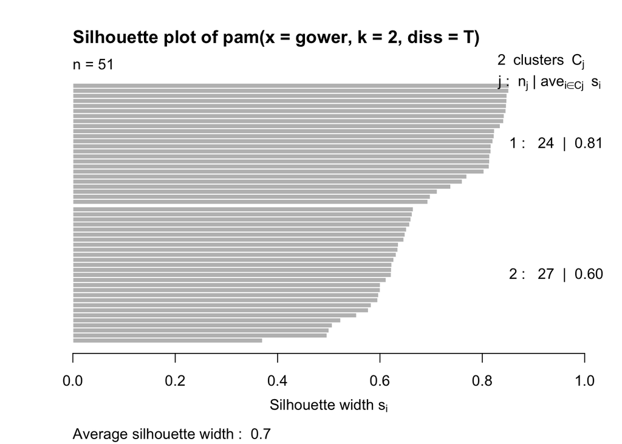

```r
plot(pam1, which = 2)
```

In this clustering analysis, I wanted to see which states were most similar in terms of Income, GDP, and Testing Numbers. We found from the silhouette width that the optimal number of clusters are two.

We found that the medoid of the first cluster is Alabama and the medoid of the second cluster is Texas. That means that these states are the most representative of their cluster. This result is surprising as these states are both similar geographically and culturally.

Our model was an average silhouette width of 0.74 which means that our model has a strong structure which is good!

Next, we used Gower’s differences to add “Pop.Density.Level” into our cluster analysis. We also found that two clusters are the optimal number clusters. We found that the medoid of the first cluster is Nevada and the medoid of the second cluster is Wisconsin. This model has an average silhouette width of 0.7 which means a reasonable structure has been found. That means that adding the variable added error into the analysis.

### Dimensionality Reduction with PCA

```r
PCA_data <- dataset %>%
    select(Income, Gini, GDP) %>%
    select_if(is.numeric) %>%
    scale

pca1 <- princomp(PCA_data)
names(pca1)
```

```
## [1] "sdev"     "loadings" "center"   "scale"    "n.obs"    "scores"   "call"
```

```r
summary(pca1, loadings = T)
```

```
## Importance of components:
##                           Comp.1    Comp.2    Comp.3
## Standard deviation     1.2258947 0.9899363 0.6770411
## Proportion of Variance 0.5109581 0.3331911 0.1558508
## Cumulative Proportion  0.5109581 0.8441492 1.0000000
##
## Loadings:
##        Comp.1 Comp.2 Comp.3
## Income  0.481  0.733  0.481
## Gini    0.518 -0.680  0.518
## GDP     0.707        -0.707
```

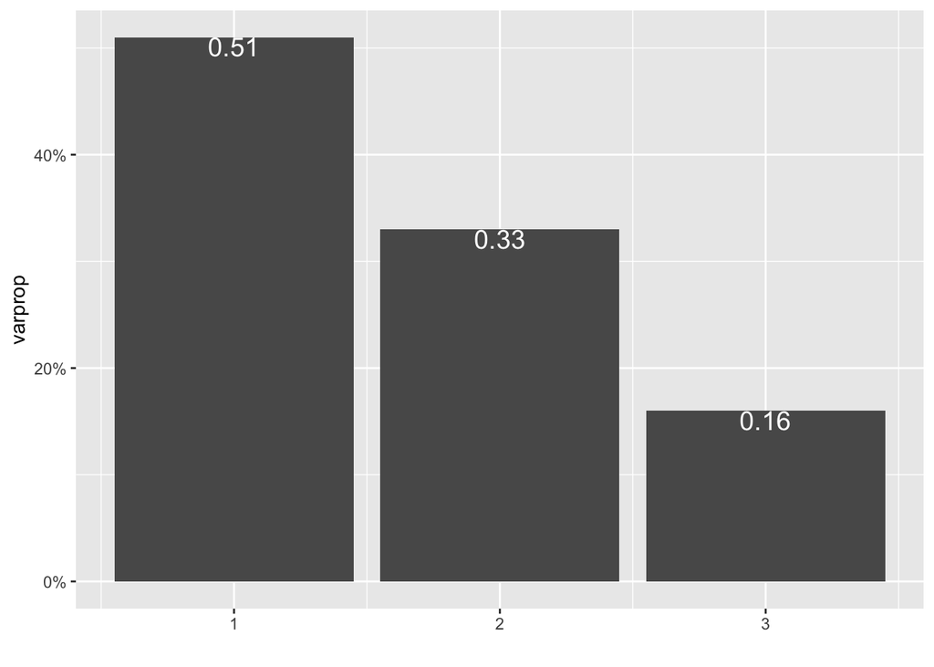

```r
# Choosing how many PCs to keep. (It seems like 2 PCs
# should be kept.)
eigval <- pca1$sdev^2
varprop = round(eigval/sum(eigval), 2)

ggplot() + geom_bar(aes(y = varprop, x = 1:3), stat = "identity") +
    xlab("") + geom_text(aes(x = 1:3, y = varprop, label = round(varprop,
    2)), vjust = 1, col = "white", size = 5) + scale_y_continuous(breaks = seq(0,
    0.6, 0.2), labels = scales::percent) + scale_x_continuous(breaks = 1:10)
```

```r
round(cumsum(eigval)/sum(eigval), 2)
```

```
## Comp.1 Comp.2 Comp.3
##   0.51   0.84   1.00
```

```r
eigval
```

```
##    Comp.1    Comp.2    Comp.3
## 1.5028179 0.9799739 0.4583847
```

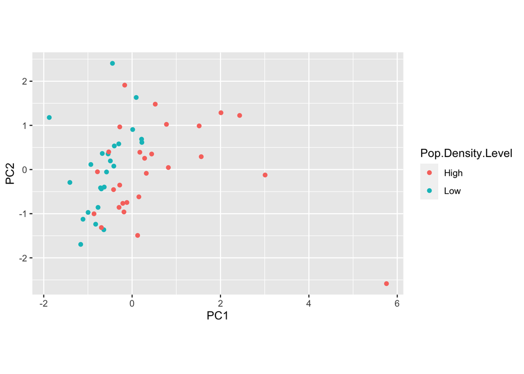

```r
# Plot of PC Scores.
PCA_data <- as.data.frame(PCA_data)
PCA_data$Pop.Density.Level <- dataset$Pop.Density.Level
PCA_data$Pop.Density.Level <- ifelse(PCA_data$Pop.Density.Level ==
    1, "High", "Low")
PCA_data %>%
    mutate(PC1 = pca1$scores[, 1], PC2 = pca1$scores[, 2]) %>%
    ggplot(aes(PC1, PC2, color = Pop.Density.Level)) + geom_point() +
    coord_fixed()
```

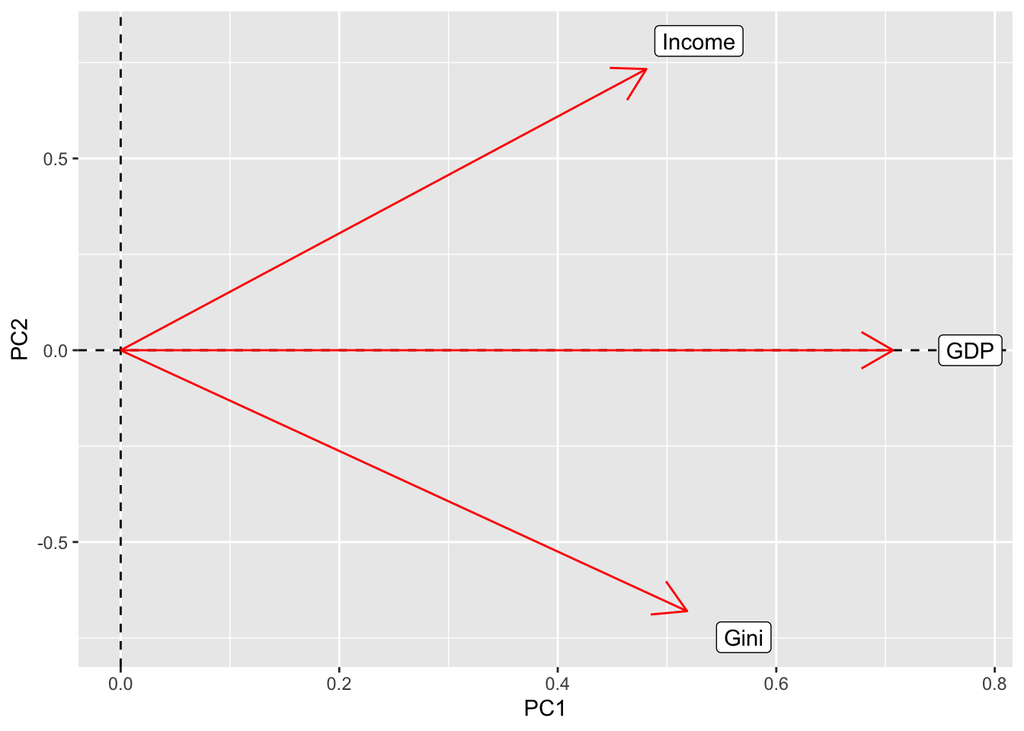

```r
# Plotting Loadings.

pca1$loadings[1:3, 1:2] %>%
    as.data.frame %>%
    rownames_to_column %>%
    ggplot() + geom_hline(aes(yintercept = 0), lty = 2) + geom_vline(aes(xintercept = 0),
    lty = 2) + ylab("PC2") + xlab("PC1") + geom_segment(aes(x = 0,
    y = 0, xend = Comp.1, yend = Comp.2), arrow = arrow(), col = "red") +
    geom_label(aes(x = Comp.1 * 1.1, y = Comp.2 * 1.1, label = rowname))
```

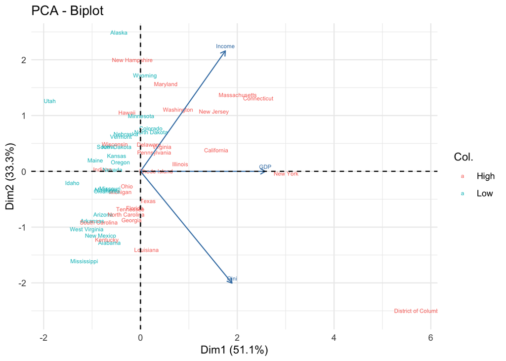

```r
library(factoextra)
fviz_pca_biplot(pca1, col.ind = PCA_data$Pop.Density.Level, geom = "text",
    labelsize = 2) + theme_minimal()
```

I found from looking at the eigenvalues and variance percentages that the optimal number of PCs to retain is 2 (the scree plot doesn’t flatten out). By choosing two PCs, the model accounts for 84% of the variance in the data which means it is a pretty good model.

By looking at the summary of the PC object, we found that the first PC is a general financial strength axis with all the variables in the column having a positive correlation. The second PC is an Income vs Gini scale which is uncorrelated to GDP. High income scores mean low Gini scores and vice versa.

### Linear Classifier and Cross-Validation

```r
library(caret)

Logregressiondata <- dataset %>%
    select(-Population)

# Logistic Regression on Dataset.

Logregressiondata$Pop.Density.Level <- as.numeric(Logregressiondata$Pop.Density.Level)
fit <- glm(Pop.Density.Level ~ Income + Gini + ICU.Beds + Income +
    GDP, data = Logregressiondata, family = binomial)
summary(fit)
```

```
##
## Call:
## glm(formula = Pop.Density.Level ~ Income + Gini + ICU.Beds +
##     Income + GDP, family = binomial, data = Logregressiondata)
##
## Deviance Residuals:
##      Min        1Q    Median        3Q       Max
## -1.99423  -0.52887   0.00158   0.45941   1.81988
##
## Coefficients:
##               Estimate Std. Error z value Pr(>|z|)
## (Intercept) -4.325e+01  2.047e+01  -2.112   0.0346 *
## Income       1.183e-04  1.300e-04   0.910   0.3630
## Gini         6.529e+01  3.758e+01   1.738   0.0823 .
## ICU.Beds     1.399e-03  6.682e-04   2.093   0.0363 *
## GDP          9.689e-05  8.058e-05   1.202   0.2292
## ---
## Signif. codes:  0 '***' 0.001 '**' 0.01 '*' 0.05 '.' 0.1 ' ' 1
##
## (Dispersion parameter for binomial family taken to be 1)
##
##     Null deviance: 70.524  on 50  degrees of freedom
## Residual deviance: 36.962  on 46  degrees of freedom
## AIC: 46.962
##
## Number of Fisher Scoring iterations: 7
```

```r
score <- predict(fit, type = "response")
head(score)
```

```
##     Alaska    Alabama   Arkansas    Arizona California   Colorado
## 0.09245180 0.48290832 0.09406771 0.38306154 0.99999875 0.86309741
```

```r
class_diag(score, dataset$Pop.Density.Level, positive = 1)
```

```
##            acc   sens   spec  ppv     f1     ba    auc
## Metrics 0.8039 0.7778 0.8333 0.84 0.8077 0.8056 0.9043
```

```r
# Confusion Matrix.

Logregressiondata$Pop.Density.Level <- ifelse(dataset$Pop.Density.Level ==
    1, TRUE, FALSE)
Logregressiondata$Pop.Density.Level <- as.factor(Logregressiondata$Pop.Density.Level)
pdata <- predict(fit, newdata = Logregressiondata, type = "response")
table(data = pdata > 0.5, reference = Logregressiondata$Pop.Density.Level)
```

```
##        reference
## data    FALSE TRUE
##   FALSE    20    6
##   TRUE      4   21
```

```r
# K-Fold CV.

Logregressiondata$Pop.Density.Level <- ifelse(Logregressiondata$Pop.Density.Level ==
    TRUE, 1, 0)
Logregressiondata$Pop.Density.Level <- as.numeric(Logregressiondata$Pop.Density.Level)

k = 5
data <- Logregressiondata[sample(nrow(Logregressiondata)), ]
folds <- cut(seq(1:nrow(Logregressiondata)), breaks = k, labels = F)
diags <- NULL

for (i in 1:k) {
    train <- data[folds != i, ]
    test <- data[folds == i, ]
    truth <- test$Pop.Density.Level
    fit <- glm(Pop.Density.Level ~ Income + Gini + ICU.Beds +
        GDP, data = train, family = binomial)
    probs <- predict(fit, newdata = test, type = "response")
    diags <- rbind(diags, class_diag(probs, truth, positive = 1))
}

summarize_all(diags, mean)
```

```
##       acc    sens    spec     ppv      f1      ba    auc
## 1 0.74546 0.66952 0.70832 0.76428 0.71064 0.68894 0.8709
```

When predicting the data using logistic regression, we get an AUC value of around 0.90. When predicting the data using K-Fold CV, we get an AUC value of around 0.87. Since the AUC values are so similar, there seems to be no signs of over fitting. My model is a strong predictor of new observations. From our confusion matrix, we can see that the majority of the predictions are correct.

### Non-Parametric Classifier and Cross-Validation

```r
library(caret)

Nonparametricdata <- dataset %>%
    select(-Population)

# Fitting Non-Parametric Classifier.

knn_fit <- knn3(factor(Pop.Density.Level == 1, levels = c("TRUE",
    "FALSE")) ~ Income + Gini + ICU.Beds + Income + GDP, data = Nonparametricdata,
    k = 5)
y_hat_knn <- predict(knn_fit, Nonparametricdata)
y_hat_knn %>%
    head(6)
```

```
##      TRUE FALSE
## [1,]  0.4   0.6
## [2,]  0.4   0.6
## [3,]  0.2   0.8
## [4,]  0.4   0.6
## [5,]  0.6   0.4
## [6,]  0.6   0.4
```

```r
data.frame(y_hat_knn, names = rownames(Nonparametricdata)) %>%
    arrange(names) %>%
    head(6)
```

```
##   TRUE. FALSE.      names
## 1   0.4    0.6    Alabama
## 2   0.4    0.6     Alaska
## 3   0.4    0.6    Arizona
## 4   0.2    0.8   Arkansas
## 5   0.6    0.4 California
## 6   0.6    0.4   Colorado
```

```r
class_diag(y_hat_knn[, 1], Nonparametricdata$Pop.Density.Level,
    positive = 1)
```

```
##            acc   sens   spec ppv     f1     ba    auc
## Metrics 0.7647 0.7407 0.7917 0.8 0.7692 0.7662 0.8333
```

```r
# Confusion Matrix.

table(truth = factor(Nonparametricdata$Pop.Density.Level == 1,
    levels = c("TRUE", "FALSE")), prediction = factor(y_hat_knn[,
    1] > 0.5, levels = c("TRUE", "FALSE")))
```

```
##        prediction
## truth   TRUE FALSE
##   TRUE    20     7
##   FALSE    5    19
```

```r
# K-Fold CV.

k = 5
data <- Nonparametricdata[sample(nrow(Nonparametricdata)), ]
folds <- cut(seq(1:nrow(Nonparametricdata)), breaks = k, labels = F)
diags <- NULL
for (i in 1:k) {
    train <- data[folds != i, ]
    test <- data[folds == i, ]
    truth <- test$Pop.Density.Level
    fit <- knn3(Pop.Density.Level ~ Income + Gini + ICU.Beds +
        Income + GDP, data = train)
    probs <- predict(fit, newdata = test)[, 2]
    diags <- rbind(diags, class_diag(probs, truth, positive = 1))
}
summarize_all(diags, mean)
```

```
##       acc    sens    spec     ppv      f1      ba     auc
## 1 0.60728 0.69526 0.54166 0.62666 0.63264 0.61846 0.70418
```

When predicting the data using knn, we get an AUC value of around 0.83. When predicting the data using K-Fold CV, we get an AUC value of around 0.70. Since the AUC values dropped in the CV, there seems to be a sign of over fitting. My model is a relatively strong predictor of new observations. From our confusion matrix, we can see that the majority of the predictions are correct. We can see that the linear model is stronger than the non linear model.

### Regression/Numeric Prediction

```r
NumericData <- dataset %>%
    select(Population, Income, GDP, Gini)

# Regression Model.

fit <- lm(Population ~ Income + GDP + Gini, data = NumericData)
yhat <- predict(fit)

# MSE.

mean((NumericData$Population - yhat)^2)
```

```
## [1] 4.071275e+13
```

```r
# K-Fold CV.

k = 5
data <- NumericData[sample(nrow(NumericData)), ]
folds <- cut(seq(1:nrow(NumericData)), breaks = k, labels = F)
diags <- NULL
for (i in 1:k) {
    train <- data[folds != i, ]
    test <- data[folds == i, ]
    fit <- lm(Population ~ ., data = train)
    yhat <- predict(fit, newdata = test)
    diags <- mean((test$Population - yhat)^2)
}

mean(diags)
```

```
## [1] 1.984225e+13
```

### Python

```r
library(reticulate)
use_python("/usr/bin/python3", required = F)
# py_install(packages = 'matplotlib')

x <- dataset$Population
y <- dataset$Gini
```

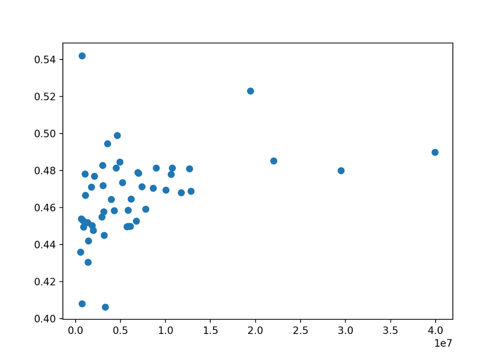

```python
import matplotlib.pyplot as plt
x = r.x
y = r.y
plt.scatter(x,y)
```

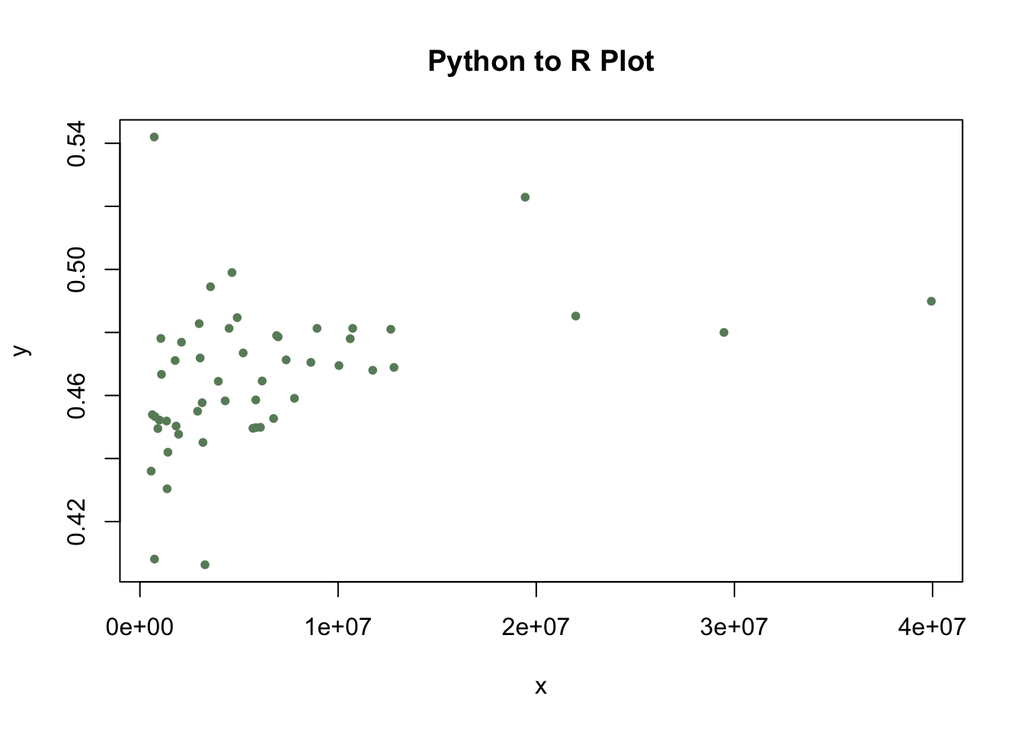

```r
x <- py$x
y <- py$y

plot(x, y, main = "Python to R Plot", col = "darkseagreen4",
    pch = 20)
```

In this example, I used r. to change 2 columns of my data into python objects and made a plot out of them using the matplotlib package. Then I converted them back into R objects using py$ and make the same plot using base R.

### Concluding Remarks

In conclusion, I found that this study confirmed what I thought all along about the relationship between wealth / resource distribution and a state’s population.